# Final_Project

Fatma KARADAĞ~Gizem PESEN

13 01 2022

Our main goal is to predict the factors affecting cancer risk by analyzing the data, to facilitate the diagnosis of patients. Because early diagnosis saves lives.

## Import Libraries

```r
library(missForest)
library(e1071)
```

```r
library(logisticPCA)
library(ggplot2)
library(nnet)
library(rpart)
library(caTools)
library(readxl)
library(corrplot)
library(Amelia)
library(mlbench)
library(caret)
library(plyr)
library(MASS)
library(dplyr)
library(factoextra)
library(cluster)
library(stats)
library(rpart.plot)
library(plotrix)
library(ROSE)
library(randomForest)
library(ggraph)
```

## Loading the Data

```r
df <- read_excel("C:/Users/ftmak/OneDrive/Masaüstü/cancer patient data sets.xlsx")
```

## Exploratory data analysis

```r
summary(df)
```

```
##   Patient Id             Age            Gender      Air Pollution
##  Length:1000        Min.   :14.00   Min.   :1.000   Min.   :1.00
##  Class :character   1st Qu.:27.75   1st Qu.:1.000   1st Qu.:2.00
##  Mode  :character   Median :36.00   Median :1.000   Median :3.00
##                     Mean   :37.17   Mean   :1.402   Mean   :3.84
##                     3rd Qu.:45.00   3rd Qu.:2.000   3rd Qu.:6.00
##                     Max.   :73.00   Max.   :2.000   Max.   :8.00
##   Alcohol use     Dust Allergy   OccuPational Hazards  Genetic Risk
##  Min.   :1.000   Min.   :1.000   Min.   :1.00         Min.   :1.00
##  1st Qu.:2.000   1st Qu.:4.000   1st Qu.:3.00         1st Qu.:2.00
##  Median :5.000   Median :6.000   Median :5.00         Median :5.00
##  Mean   :4.563   Mean   :5.165   Mean   :4.84         Mean   :4.58
##  3rd Qu.:7.000   3rd Qu.:7.000   3rd Qu.:7.00         3rd Qu.:7.00
##  Max.   :8.000   Max.   :8.000   Max.   :8.00         Max.   :7.00
##  chronic Lung Disease Balanced Diet      Obesity         Smoking
##  Min.   :1.00         Min.   :1.000   Min.   :1.000   Min.   :1.000
##  1st Qu.:3.00         1st Qu.:2.000   1st Qu.:3.000   1st Qu.:2.000
##  Median :4.00         Median :4.000   Median :4.000   Median :3.000
##  Mean   :4.38         Mean   :4.491   Mean   :4.465   Mean   :3.948
##  3rd Qu.:6.00         3rd Qu.:7.000   3rd Qu.:7.000   3rd Qu.:7.000
##  Max.   :7.00         Max.   :7.000   Max.   :7.000   Max.   :8.000
##  Passive Smoker    Chest Pain    Coughing of Blood    Fatigue
##  Min.   :1.000   Min.   :1.000   Min.   :1.000     Min.   :1.000
##  1st Qu.:2.000   1st Qu.:2.000   1st Qu.:3.000     1st Qu.:2.000
##  Median :4.000   Median :4.000   Median :4.000     Median :3.000
##  Mean   :4.195   Mean   :4.438   Mean   :4.859     Mean   :3.856
##  3rd Qu.:7.000   3rd Qu.:7.000   3rd Qu.:7.000     3rd Qu.:5.000
##  Max.   :8.000   Max.   :9.000   Max.   :9.000     Max.   :9.000
##   Weight Loss    Shortness of Breath    Wheezing     Swallowing Difficulty
##  Min.   :1.000   Min.   :1.00        Min.   :1.000   Min.   :1.000
##  1st Qu.:2.000   1st Qu.:2.00        1st Qu.:2.000   1st Qu.:2.000
##  Median :3.000   Median :4.00        Median :4.000   Median :4.000
##  Mean   :3.855   Mean   :4.24        Mean   :3.777   Mean   :3.746
##  3rd Qu.:6.000   3rd Qu.:6.00        3rd Qu.:5.000   3rd Qu.:5.000
##  Max.   :8.000   Max.   :9.00        Max.   :8.000   Max.   :8.000
##  Clubbing of Finger Nails Frequent Cold     Dry Cough        Snoring
##  Min.   :1.000            Min.   :1.000   Min.   :1.000   Min.   :1.000
##  1st Qu.:2.000            1st Qu.:2.000   1st Qu.:2.000   1st Qu.:2.000
##  Median :4.000            Median :3.000   Median :4.000   Median :3.000
##  Mean   :3.923            Mean   :3.536   Mean   :3.853   Mean   :2.926
##  3rd Qu.:5.000            3rd Qu.:5.000   3rd Qu.:6.000   3rd Qu.:4.000
##  Max.   :9.000            Max.   :7.000   Max.   :7.000   Max.   :7.000
##     Level
##  Length:1000
##  Class :character
##  Mode  :character
##
##
##
```

```r
head(df,n=6)
```

```
## # A tibble: 6 x 25
##   `Patient Id`   Age Gender `Air Pollution` `Alcohol use` `Dust Allergy`
##   <chr>        <dbl>  <dbl>           <dbl>         <dbl>          <dbl>
## 1 P1              33      1               2             4              5
## 2 P10             17      1               3             1              5
## 3 P100            35      1               4             5              6
## 4 P1000           37      1               7             7              7
## 5 P101            46      1               6             8              7
## 6 P102            35      1               4             5              6
## # ... with 19 more variables: OccuPational Hazards <dbl>, Genetic Risk <dbl>,
## #   chronic Lung Disease <dbl>, Balanced Diet <dbl>, Obesity <dbl>,
## #   Smoking <dbl>, Passive Smoker <dbl>, Chest Pain <dbl>,
## #   Coughing of Blood <dbl>, Fatigue <dbl>, Weight Loss <dbl>,
## #   Shortness of Breath <dbl>, Wheezing <dbl>, Swallowing Difficulty <dbl>,
## #   Clubbing of Finger Nails <dbl>, Frequent Cold <dbl>, Dry Cough <dbl>,
## #   Snoring <dbl>, Level <chr>
```

```r
colnames(df)
```

```
##  [1] "Patient Id"               "Age"
##  [3] "Gender"                   "Air Pollution"
##  [5] "Alcohol use"              "Dust Allergy"
##  [7] "OccuPational Hazards"     "Genetic Risk"
##  [9] "chronic Lung Disease"     "Balanced Diet"
## [11] "Obesity"                  "Smoking"
## [13] "Passive Smoker"           "Chest Pain"
## [15] "Coughing of Blood"        "Fatigue"
## [17] "Weight Loss"              "Shortness of Breath"
## [19] "Wheezing"                 "Swallowing Difficulty"
## [21] "Clubbing of Finger Nails" "Frequent Cold"
## [23] "Dry Cough"                "Snoring"
## [25] "Level"
```

Patient Id refers to the people whose data is received. The level of the disease is divided into three as “Low”, “Medium” and “High” with the Level column. **Age:** What is the relationship between age and disease level? **Gender:** do women or men get lung cancer more often? Is gender a factor in this? **Smoking , Passive Smoker , Alcohol use :** Do harmful substances affect lung cancer? **Diet , Obesity:** What is the effect of eating habits on cancer? **Genetic Risk, chronic Lung Disease :** what is the effect of genetic or chronic diseases on cancer? **Air Pollution, Dust Allergy , OccuPational Hazards :** how do environmental influences relate to lung cancer? **Snoring , Dry Cough , Frequent Cold, Clubbing of Finger Nails , Swallowing Difficulty , Wheezing , Shortness of Breath , Weight Loss , Fatigue , Coughing of Blood , Chest Pain :** Which symptoms are decisive for the diagnosis of lung cancer?

```r
colnames(df) <- c("patiend_id", "age",
                       "gender", "air_pollution", "alcohol_use","dust_allergy", "occupational_hazards","genetic_risk","chronic_lung_disease","balanced_diet","obesity","smoking","passive_smoker","chest_pain","coughing_of_blood","fatigue","weight_loss","shortness_of_breath","wheezing","swallowing_difficulty","clubbing_of_finger_nails","frequent_cold","dry_cough","snoring","level")
```

We changed the column names and made them more understandable. Also, having a space in the column name caused us trouble in the future.

```r
colnames(df)
```

```
##  [1] "patiend_id"               "age"
##  [3] "gender"                   "air_pollution"
##  [5] "alcohol_use"              "dust_allergy"
##  [7] "occupational_hazards"     "genetic_risk"
##  [9] "chronic_lung_disease"     "balanced_diet"
## [11] "obesity"                  "smoking"
## [13] "passive_smoker"           "chest_pain"
## [15] "coughing_of_blood"        "fatigue"
## [17] "weight_loss"              "shortness_of_breath"
## [19] "wheezing"                 "swallowing_difficulty"
## [21] "clubbing_of_finger_nails" "frequent_cold"
## [23] "dry_cough"                "snoring"
## [25] "level"
```

```r
sapply(df,class)
```

```
##               patiend_id                      age                   gender
##              "character"                "numeric"                "numeric"
##            air_pollution              alcohol_use             dust_allergy
##                "numeric"                "numeric"                "numeric"
##     occupational_hazards             genetic_risk     chronic_lung_disease
##                "numeric"                "numeric"                "numeric"
##            balanced_diet                  obesity                  smoking
##                "numeric"                "numeric"                "numeric"
##           passive_smoker               chest_pain        coughing_of_blood
##                "numeric"                "numeric"                "numeric"
##                  fatigue              weight_loss      shortness_of_breath
##                "numeric"                "numeric"                "numeric"
##                 wheezing    swallowing_difficulty clubbing_of_finger_nails
##                "numeric"                "numeric"                "numeric"
##            frequent_cold                dry_cough                  snoring
##                "numeric"                "numeric"                "numeric"
##                    level
##              "character"
```

We have printed the data type of the columns, in this way, when we need to get numeric values, we will be able to decide which range to take from our data.

```r
s1 <- dplyr::select(df, age:smoking)
s1
```

```
## # A tibble: 1,000 x 11
##      age gender air_pollution alcohol_use dust_allergy occupational_hazards
##    <dbl>  <dbl>         <dbl>       <dbl>        <dbl>                <dbl>
##  1    33      1             2           4            5                    4
##  2    17      1             3           1            5                    3
##  3    35      1             4           5            6                    5
##  4    37      1             7           7            7                    7
##  5    46      1             6           8            7                    7
##  6    35      1             4           5            6                    5
##  7    52      2             2           4            5                    4
##  8    28      2             3           1            4                    3
##  9    35      2             4           5            6                    5
## 10    46      1             2           3            4                    2
## # ... with 990 more rows, and 5 more variables: genetic_risk <dbl>,
## #   chronic_lung_disease <dbl>, balanced_diet <dbl>, obesity <dbl>,
## #   smoking <dbl>
```

From these variables, we selected all the variables between the “Age” and “Smoking” and defined them as “s1”.

```r
df %>%
    select(age , level) %>%
    filter(age > 63)
```

```
## # A tibble: 30 x 2
##      age level
##    <dbl> <chr>
##  1    64 High
##  2    73 Medium
##  3    65 Medium
##  4    65 Medium
##  5    64 High
##  6    73 Medium
##  7    65 Medium
##  8    64 High
##  9    73 Medium
## 10    65 Medium
## # ... with 20 more rows
```

We looked at the level (high-medium-low) of the disease in people older than 63 years of age.We realızed there are only “Hıgh” or “Medıum” levels. So we can generalıze old people lung cancer rısk ıs more because there ıs no “Low” level ın ıt.

```r
df %>%
    select(age , level) %>%
    filter(age < 40)
```

```
## # A tibble: 659 x 2
##      age level
##    <dbl> <chr>
##  1    33 Low
##  2    17 Medium
##  3    35 High
##  4    37 High
##  5    35 High
##  6    28 Low
##  7    35 Medium
##  8    39 Medium
##  9    34 High
## 10    27 Low
## # ... with 649 more rows
```

```r
select(df,obesity, level)
```

```
## # A tibble: 1,000 x 2
##    obesity level
##      <dbl> <chr>
##  1       4 Low
##  2       2 Medium
##  3       7 High
##  4       7 High
##  5       7 High
##  6       7 High
##  7       4 Low
##  8       3 Low
##  9       5 Medium
## 10       3 Medium
## # ... with 990 more rows
```

## Visualization Techniques

```r
df$gender <- as.factor(df$gender)
summary(df$gender)
```

```
##   1   2
## 598 402
```

1 is male,2 is female

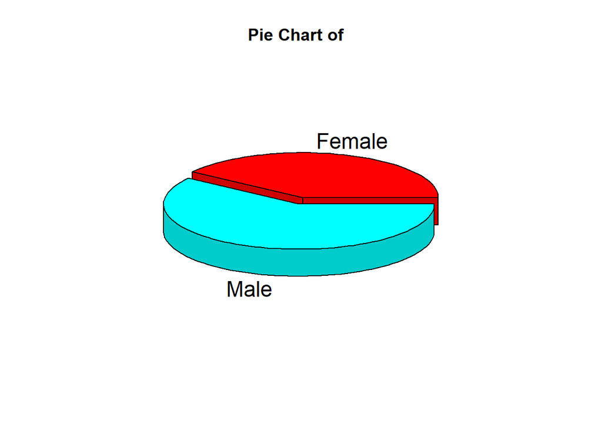

```r
slices <- c( 402, 598)
lbls <- c("Female" ,"Male")
pie3D(slices,labels=lbls,explode=0.05,
   main="Pie Chart of  ")
```

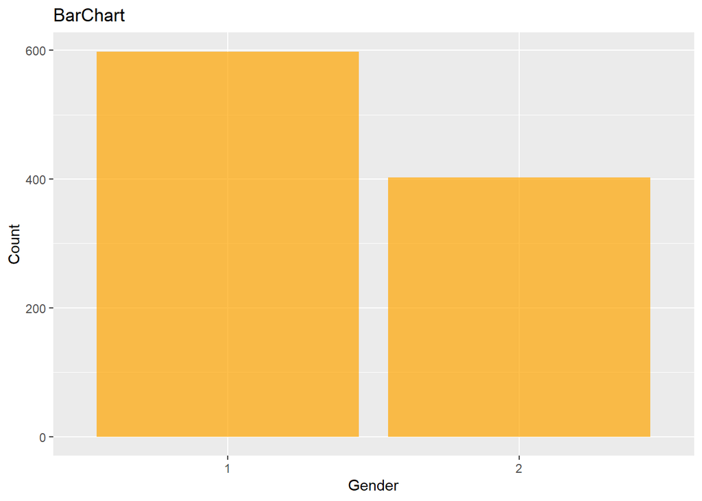

```r
ggplot(data=df, aes(x=gender)) +
  geom_bar(fill="orange", alpha=0.7)+
  labs(title = "BarChart", x="Gender", y="Count")
```

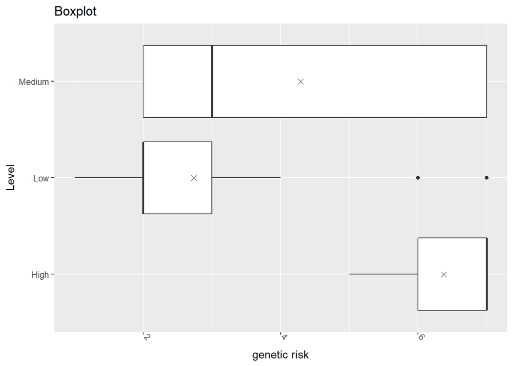

```r
ggplot(data=df, aes(x=genetic_risk, y=level, fill= genetic_risk)) +
  geom_boxplot() +
  labs(title = "Boxplot", x="genetic risk", y="Level") +
  stat_summary(fun=mean, geom="point", shape=4, size=2) +
  theme(axis.text.x=element_text(angle=-45,hjust=0,vjust=0))
```

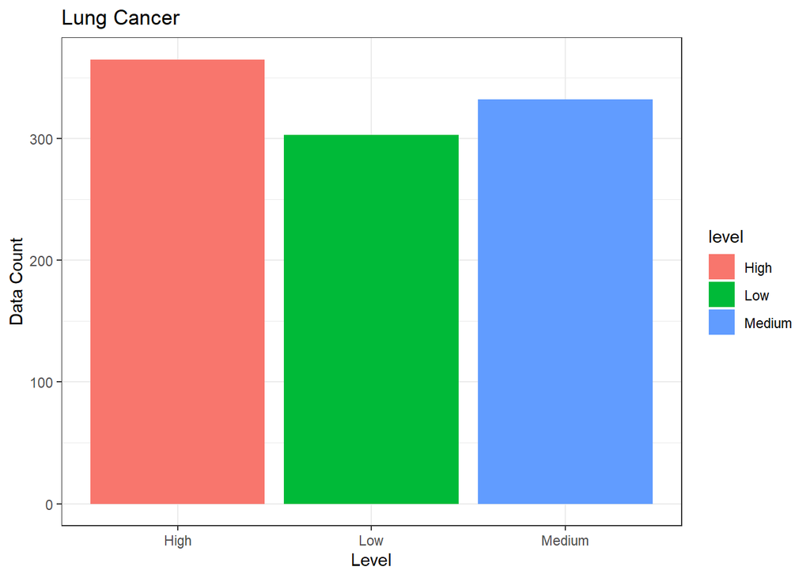

```r
ggplot(df, aes(x=level,fill = level))+
  theme_bw()+
  geom_bar()+
  labs(x = "Level", y = "Data Count", title="Lung Cancer")
```

We analyzed the general lung cancer level in all patients with this diagram. The ratio was compatible.

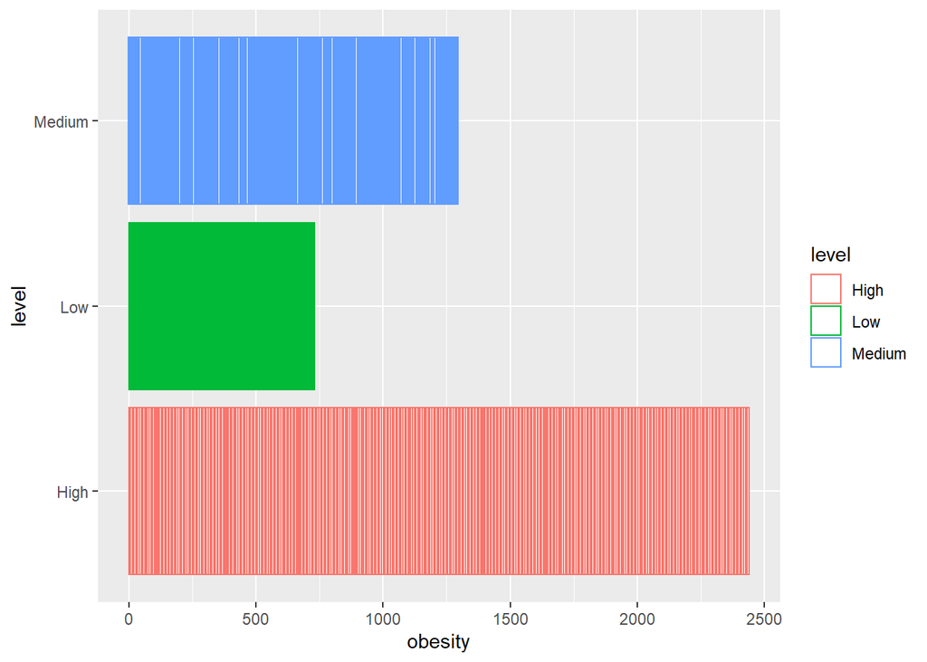

```r
p<-ggplot(df, aes(x=obesity, y=level, color=level)) +
  geom_bar(stat="identity", fill="white")
p
```

We investigated whether obesity is a value affecting lung cancer. Obese people have a “High” level of lung cancer as seen in the diagram.

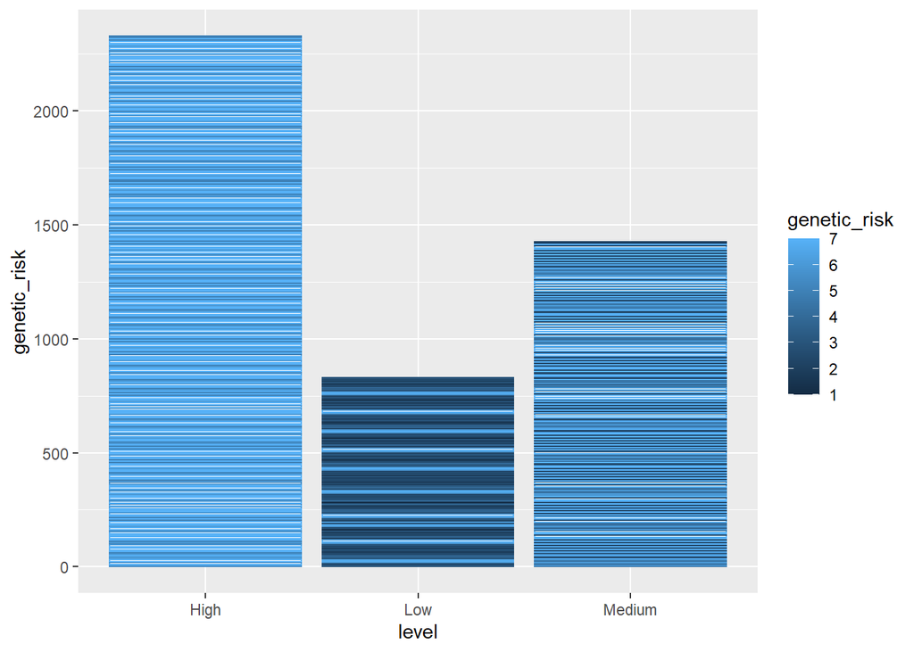

```r
a <- ggplot(df, aes(x= level, y=genetic_risk, color=genetic_risk)) +
  geom_bar(stat="identity", fill="white")
a
```

We examined the relationship between genetic risk and lung cancer level. Numbering the genetic risk between 1-7; **dark blue:** little, **light blue:** if we color it as genetic risk. In the image, we see patients with **high genetic risk in those with “High” lung levels, and people with no or low genetic risk in the “Low” section.**

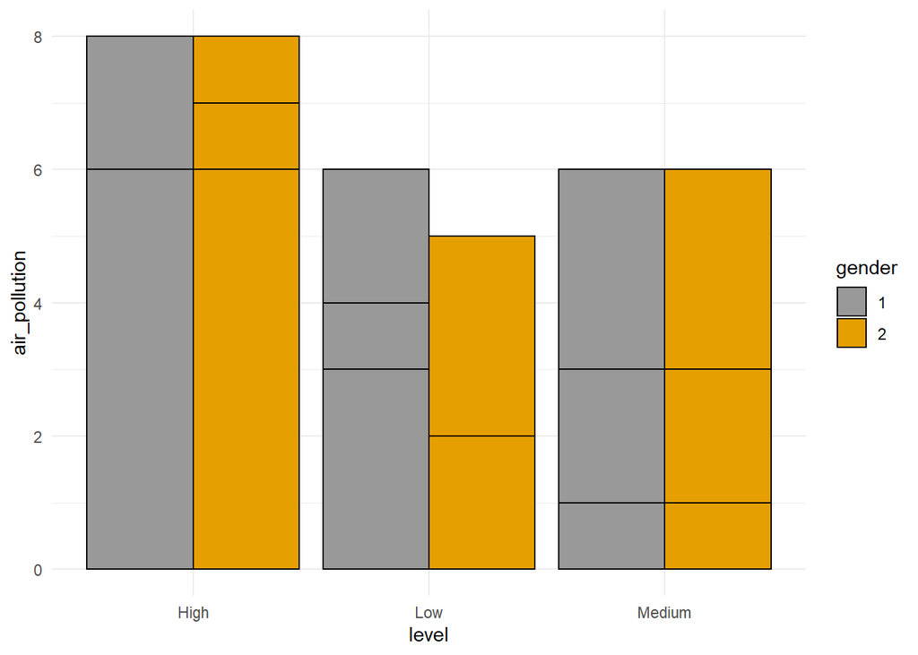

```r
b <- ggplot(data=df, aes(x=level, y=air_pollution, fill=gender)) +
geom_bar(stat="identity", color="black", position=position_dodge())+
  theme_minimal()
b + scale_fill_manual(values=c('#999999','#E69F00'))
```

## Checking Missing data

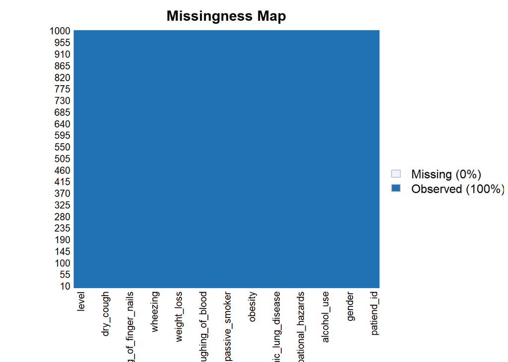

```r
missmap(df)
```

Looking at the image above, it is clear that there is no missing value in our data. Therefore, we do not need to delete or change any columns.

## Checking imbalanced data

```r
table(df$level)
```

```
##
##   High    Low Medium
##    365    303    332
```

```r
prop.table(table(df$level))
```

```
##
##   High    Low Medium
##  0.365  0.303  0.332
```

The level column we used in our data is in a balanced state. That is, since **there are such small differences between them**, they can be ignored in the classification and clustering processes. In other words, in line with what we read and what is explained in the lesson, it will not cause us a big problem.

## Multicolinearity

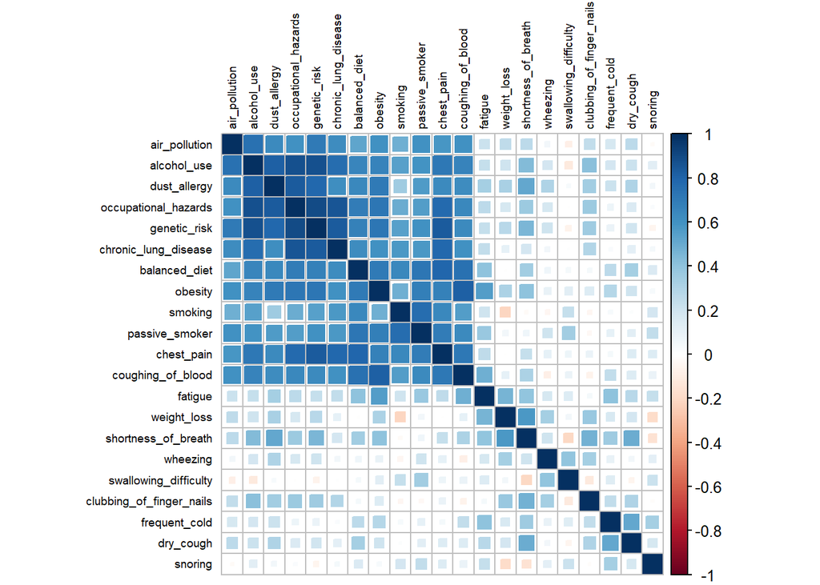

```r
correlations <- cor(df[c(4:24)])
corrplot::corrplot(correlations,method = "square",tl.cex = 0.6, tl.col = "black")
```

As you see above some of our columns have a strong positive correlation between them.That problem name is multicolinearity.

## Apply PCA

The basic logic behind PCA is to represent a multidimensional data with fewer variables by capturing the essential features in the data.

```r
pca <- prcomp(df[,4:7], cor=TRUE, scale = TRUE)
```

We got the first 4 values that are numeric so the range is between 4 and 7.

```r
summary(pca)
```

```
## Importance of components:
##                           PC1    PC2     PC3     PC4
## Standard deviation     1.8091 0.6663 0.43362 0.30843
## Proportion of Variance 0.8182 0.1110 0.04701 0.02378
## Cumulative Proportion  0.8182 0.9292 0.97622 1.00000
```

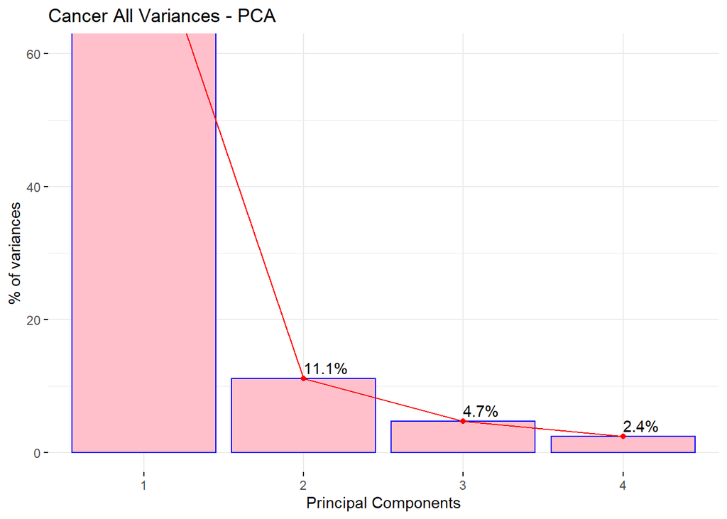

```r
fviz_eig(pca, addlabels=TRUE, ylim=c(0,60), geom = c("bar", "line"), barfill = "pink",
         barcolor="blue",linecolor = "red", ncp=10)+
         labs(title = "Cancer All Variances - PCA",
          x = "Principal Components", y = "% of variances")
```

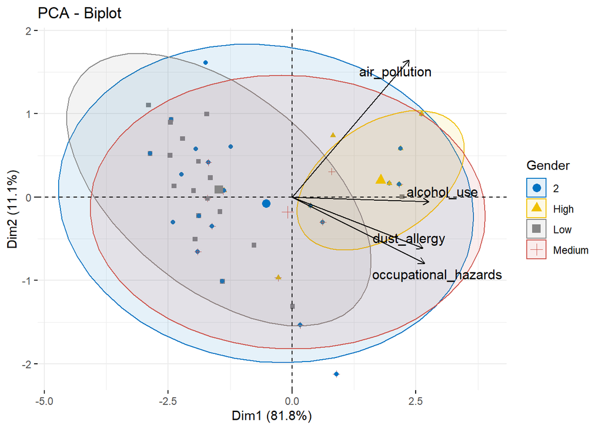

```r
df$level[df$gender==4] = '1'
df$level[df$gender==2] = '2'

fviz_pca_biplot(pca, col.ind = df$level, col="black",
                palette = "jco", geom = "point", repel=TRUE,
                legend.title="Gender", addEllipses = TRUE)
```

When we look at the first 3 components of our PCA results, it is enough for us to reach a great figure of approximately 97%

When we look at the pca values, the Standard Deviation value is decreasing as it should be. Proportion of Variance value decreases, Cumulative Proportion value increases.

## Apply Logistic Regression

Logistic regression is used to describe data and explain the relationship between a dependent binary variable and one or more nominal, inter-row, interval, or ratio-level independent variables.

dependet variable is gender in our data.

```r
df$gender <- as.factor(df$gender)
set.seed(123)

sample<- createDataPartition(y= df$gender,p=0.8,list = FALSE)

train_data <- df[sample,]
test_data <- df[-sample,]
```

```r
logistic_model <- glm(gender~.,data = train_data,family = "binomial")
```

```
## Warning: glm.fit: algorithm did not converge
```

```r
prediction <- predict(logistic_model, data = train_data, type = "response")

b <- factor(ifelse(prediction>0.5,"1","2"))

confmatrix <-table(Actual_value=train_data$gender,Predicted_value=prediction >0.5)
#confmatrix

confusionMatrix(train_data$gender,as.factor(b))
```

```
## Confusion Matrix and Statistics
##
##           Reference
## Prediction   1   2
##          1   0 479
##          2 322   0
##
##                Accuracy : 0
##                  95% CI : (0, 0.0046)
##     No Information Rate : 0.598
##     P-Value [Acc > NIR] : 1
##
##                   Kappa : -0.926
##
##  Mcnemar's Test P-Value : 3.548e-08
##
##             Sensitivity : 0.000
##             Specificity : 0.000
##          Pos Pred Value : 0.000
##          Neg Pred Value : 0.000
##              Prevalence : 0.402
##          Detection Rate : 0.000
##    Detection Prevalence : 0.598
##       Balanced Accuracy : 0.000
##
##        'Positive' Class : 1
##
```

Although we chose the binomial(boolean) column required for logistic regression, we get an unusual result here.

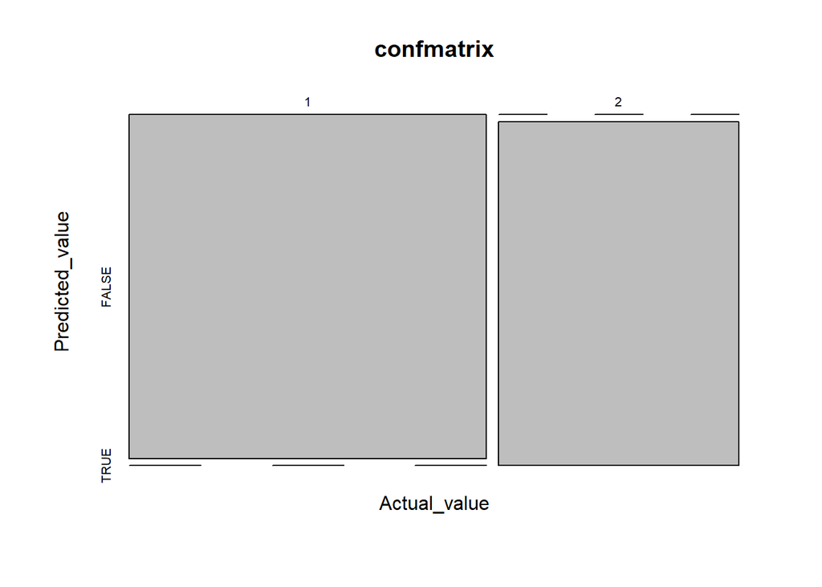

```r
plot(confmatrix)
```

## Apply Linear Regression

Let’s guess what is the average age of people with chronic level 7 with linear reggession.

```r
linearMod <- lm(age ~chronic_lung_disease, data=df)  # build linear regression model on full data
summary(linearMod)
```

```
##
## Call:
## lm(formula = age ~ chronic_lung_disease, data = df)
##
## Residuals:
##     Min      1Q  Median      3Q     Max
## -23.693  -9.018  -2.018   7.982  35.307
##
## Coefficients:
##                      Estimate Std. Error t value Pr(>|t|)
## (Intercept)           33.5058     0.9691  34.573  < 2e-16 ***
## chronic_lung_disease   0.8375     0.2039   4.108 4.32e-05 ***
## ---
## Signif. codes:  0 '***' 0.001 '**' 0.01 '*' 0.05 '.' 0.1 ' ' 1
##
## Residual standard error: 11.91 on 998 degrees of freedom
## Multiple R-squared:  0.01663,    Adjusted R-squared:  0.01564
## F-statistic: 16.88 on 1 and 998 DF,  p-value: 4.318e-05
```

```r
a <- data.frame(chronic_lung_disease = 7)
result <-  predict(linearMod,a)
print(result)
```

```
##        1
## 39.36824
```

```r
b <- data.frame(chronic_lung_disease = 3)
result <-  predict(linearMod,b)
print(result)
```

```
##        1
## 36.01825
```

As can be seen, people with low chronic level are younger, so the average age is younger than the other. In this case, it is taken into account using linear reggession.

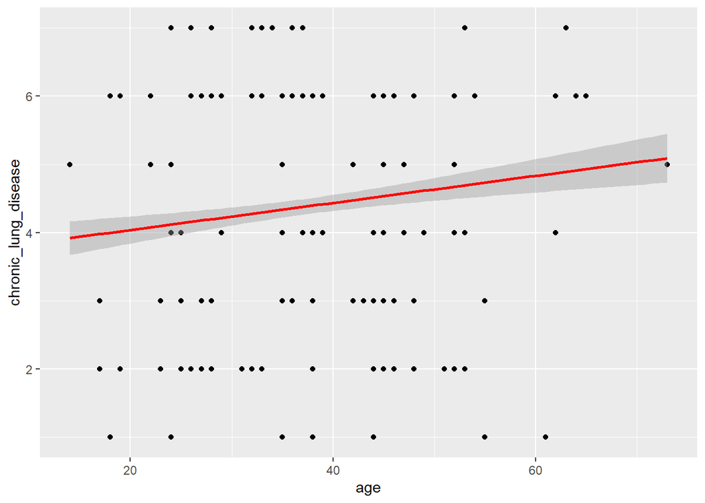

```r
ggplot(df, aes(x = age, y = chronic_lung_disease)) +
  geom_point() +
  stat_smooth(method = "lm", col = "red")
```

It is visualized the relationship between age and chronic_lung_disease with linear regression model.

## Apply Clustering Techniques

```r
df_pr <- prcomp(df[,c(4:7)], center = TRUE, scale = TRUE)
summary(df_pr)
```

```
## Importance of components:
##                           PC1    PC2     PC3     PC4
## Standard deviation     1.8091 0.6663 0.43362 0.30843
## Proportion of Variance 0.8182 0.1110 0.04701 0.02378
## Cumulative Proportion  0.8182 0.9292 0.97622 1.00000
```

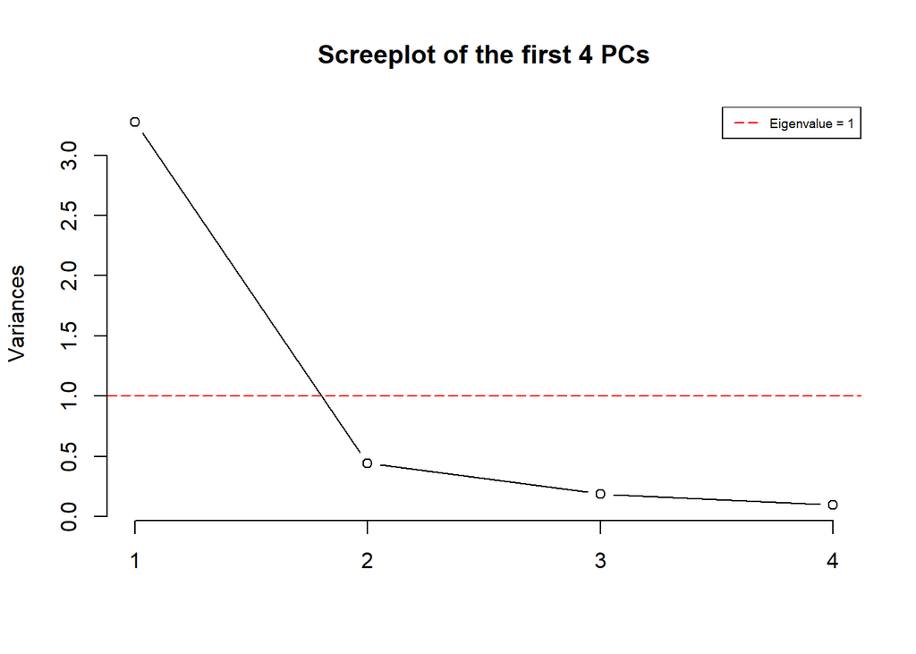

```r
screeplot(df_pr, type = "l", npcs = 4, main = "Screeplot of the first 4 PCs")
abline(h = 1, col="red", lty=5)
legend("topright", legend=c("Eigenvalue = 1"),
       col=c("red"), lty=5, cex=0.6)
```

[figure not shown]

```r
plot(df_pr$x[,1],df_pr$x[,2], xlab="PC1 (82%)", ylab = "PC2 (0,8%)", main = "PC1 / PC2 - plot")
```

## KMeans

[figure not shown]

```r
set.seed(101)
km <- kmeans(df[,4:7], 2)
plot(df_pr$x[,1],df_pr$x[,2], xlab="PC1 (82%)",
     ylab = "PC2 (0,8%)",
     main = "PC1 / PC2 - plot",
     col=km$cluster)
```

```r
km$centers
```

```
##   air_pollution alcohol_use dust_allergy occupational_hazards
## 1      2.334021    2.103093     3.402062             3.000000
## 2      5.258252    6.879612     6.825243             6.572816
```

```r
table(km$cluster, df$level)
```

```
##
##       2 High Low Medium
##   1 234   11 139    101
##   2 168  241  10     96
```

km centers ile 4 ve 7 arasındaki columnların centerslarını bulur. sonra da level ile kümeleme yapar.

[figure not shown]

```r
set.seed(102)
km <- kmeans(df[,4:7], 3)
plot(df_pr$x[,1],df_pr$x[,2], xlab="PC1 (82%)",
     ylab = "PC2 (0.08%)",
     main = "PC1 / PC2 - plot",
     col=km$cluster)
```

```r
km
```

```
## K-means clustering with 3 clusters of sizes 162, 485, 353
##
## Cluster means:
##   air_pollution alcohol_use dust_allergy occupational_hazards
## 1      1.376543    3.617284     4.370370             4.617284
## 2      5.521649    6.934021     6.814433             6.670103
## 3      2.660057    1.739377     3.263456             2.427762
##
## Clustering vector:
##    [1] 1 3 2 2 2 2 1 3 2 3 2 2 2 2 3 2 3 2 2 1 2 2 2 2 2 2 3 3 2 1 1 1 2 1 3 1 3
##   [38] 2 1 1 3 3 3 1 3 3 2 1 3 3 3 3 3 3 3 3 3 2 3 3 3 3 3 1 2 3 3 2 2 1 1 2 3 3
##   [75] 2 3 3 2 1 2 1 2 2 3 3 1 2 2 2 2 2 2 2 2 2 2 2 2 2 2 2 3 2 2 2 2 2 2 2 2 2
##  [112] 2 3 3 2 2 2 1 3 2 3 2 2 2 2 3 2 3 2 2 1 2 2 2 2 1 2 3 3 2 1 1 1 2 1 3 1 3
##  [149] 2 1 1 3 3 3 1 3 3 1 1 3 3 3 3 3 3 3 3 3 2 3 3 3 3 3 1 2 3 3 2 1 1 1 2 3 3
##  [186] 2 3 3 2 1 3 1 2 2 3 3 1 2 2 2 2 3 2 2 2 2 2 2 2 2 2 2 2 2 2 2 2 2 2 2 2 2
```

[output cut: 31 more lines]

```r
table(km$cluster, df$level)
```

```
##
##       2 High Low Medium
##   1  79   11  41     31
##   2 147  241  10     87
##   3 176    0  98     79
```

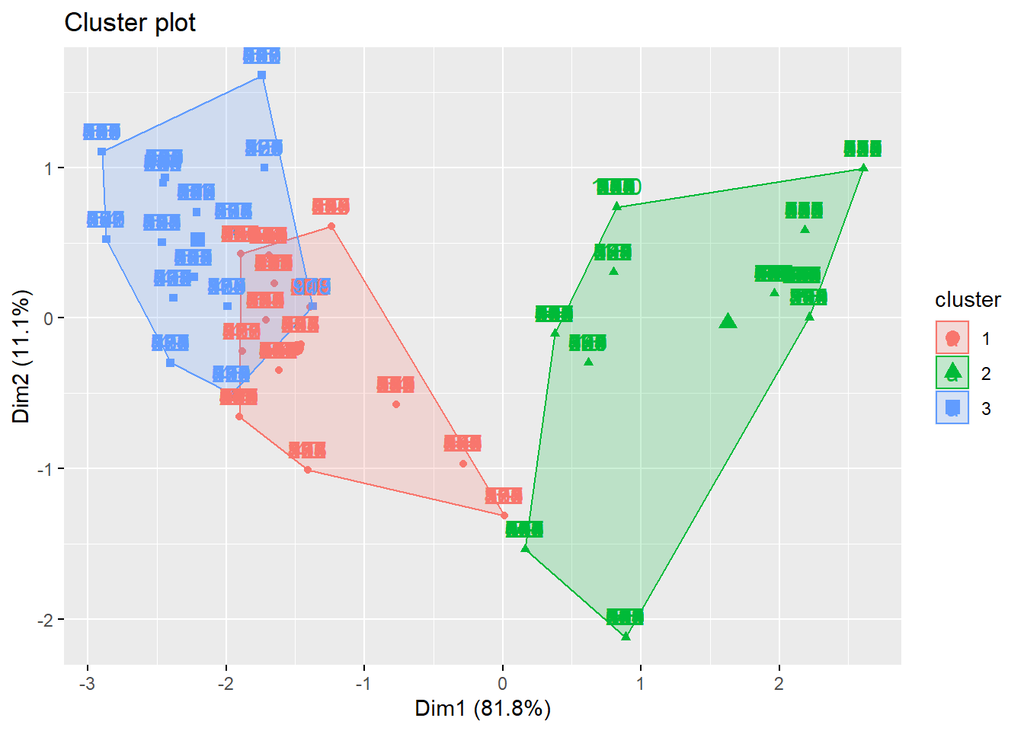

```r
km <- kmeans(df[,4:7], 3)
#We can also plot clusters with fviz_cluster() function
fviz_cluster(km, data = df[,4:7])
```

In the data we applied PCA, columns 4 and 7 are numeric values. Therefore, column selection was made in that value range. For the k point, the value of 3 is taken and the center points are found, and a clustering process is performed for these center points.

Finally, as seen above, kmeans aggregation was performed and visualized.

## Hierchical

As the name suggests, hierarchical clustering is a clustering algorithm. There are two different variations: Agglomerative (from the part to the whole) and Divisive (from the whole to the part).

Clusters that are close to each other in terms of distance merge to form a new cluster.

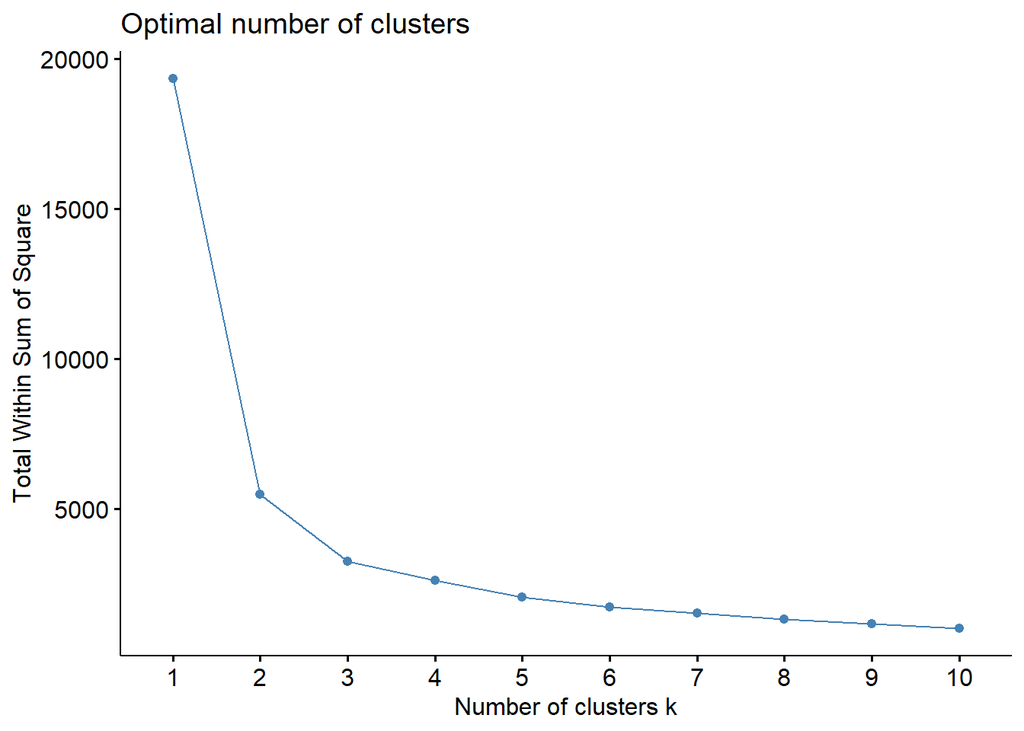

```r
distance <- dist(df[,4:7], method="euclidean")

fviz_nbclust(df[,4:7], FUN = hcut, method = "wss")
```

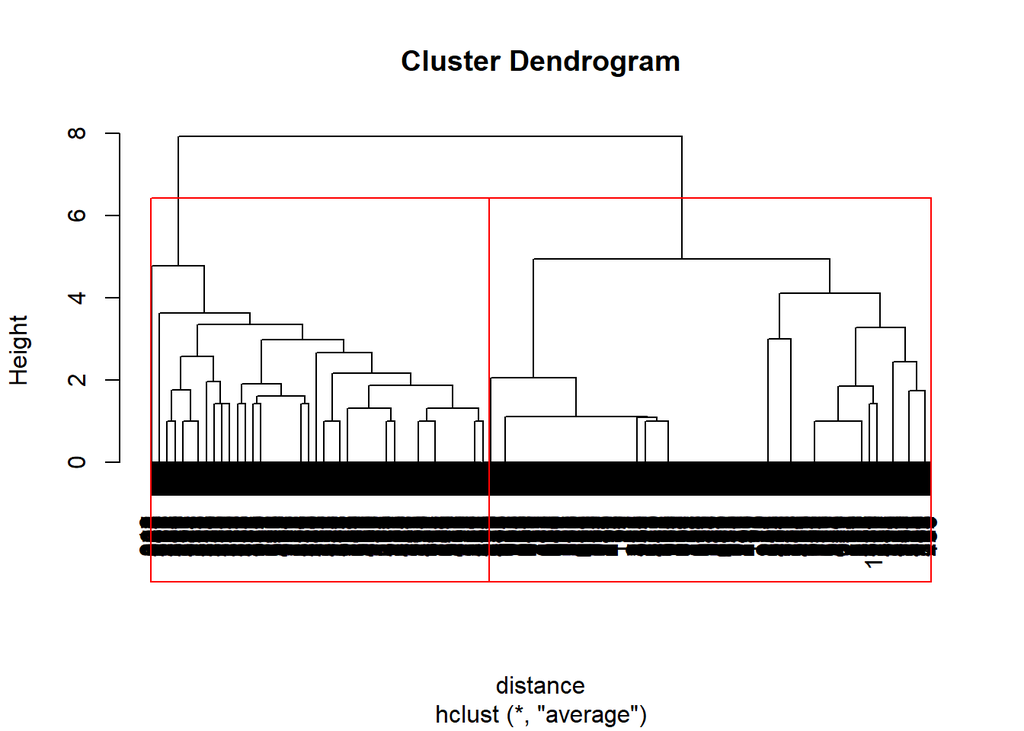

```r
hier <- hclust(distance, method="average")
plot(hier)
rect.hclust(hier, k=2, border="red")
```

```r
hier_cut <- cutree(hier, 2)
table(predicted=hier_cut, true=df$level)
```

```
##          true
## predicted   2 High Low Medium
##         1 169  251  40    106
##         2 233    1 109     91
```

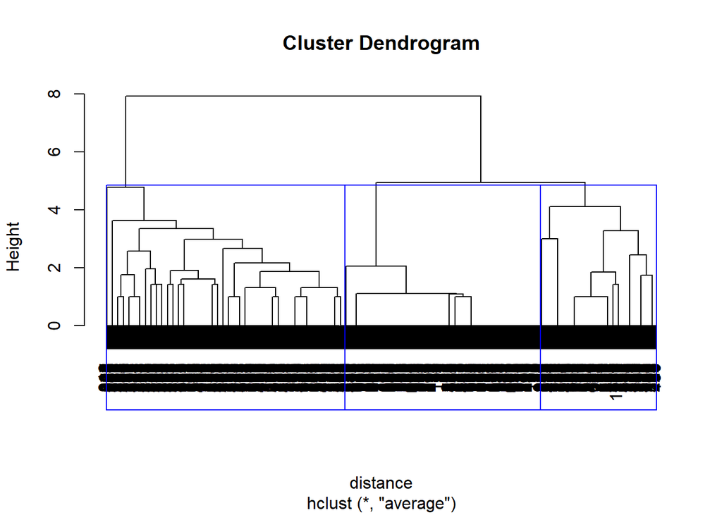

```r
plot(hier)
rect.hclust(hier, k=3, border="blue")
```

```r
distance <- dist(df[,4:7], method="euclidean")
hier_diana <- diana(df[,4:7])
# Divise coefficient; amount of clustering structure found
hier_diana$dc
```

```
## [1] 1
```

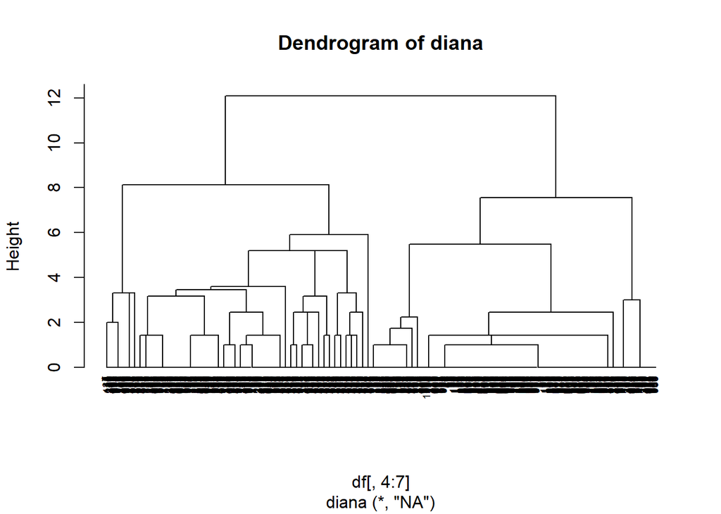

```r
pltree(hier_diana, cex = 0.6, hang = -1, main = "Dendrogram of diana")
```

We calculated the distances between these parts and continued in this way and tried to collect the parts close to each other by clustering them.